# GP2 Tutorial - Module 7 - Introduction to Workflows and WDL

`GP2 ❤️ Open Science 😍`

### Quick Description

These notebooks serve as a beginner's introduction to Terra, GP2, and AMP-PD data to help you get comfortable navigating the spaces, manage your costs, upload your own data, and begin running some simple analyses.

### Course Summary

- **Module 1:** Intro + demo Terra
- **Module 2:** Introduction to current AMP and GP2 data + managing costs
- **Module 3:** How to upload, access, and copy over data
- **Module 4:** How to interact with clinical data + make mini covariate files
- **Module 5:** Analysis example 1: Run PRS with PD known hits in Non-Euro pops and data viz + save results
- **Module 6:** Analysis example 2: How to extract a gene, annotate it, run burden, and get hmz and compound hets + save results
- **Module 7:** WDL workflows: What they are + When to use + Quick example overview **(this notebook!)**

## Notebook Summary

- What are workflows?
- When to use workflows
- WDL basics and structure
- How to use available workflows and make your own
- Demo - make and run your own workflow

## Workflow

### What are workflows?

This section goes through:

- Overview of workflows and the steps

### When to use workflows

This section goes through:

- Examples of when to use workflows

### WDL basics and structure

This section goes through:

- The language and structure of a workflow
- An example of a workflow that converts vcf to plink2 files

### How to use available workflows

This section goes through:

- How to move Terra and Broad repository workflows to your workspace

### Demo - make and run your own workflow

This section goes through:

- Write our own workflow, submit it, and then check the results

# What are workflows?

Terra uses workflows written with Workflow Description Langauge (WDL) to run batch jobs. They are pipelines with inndividual steps that are performed by an external compute engine. As an alternative analysis choice to notebooks, these are often used for for automated, bulk analysis (such as aligning genomic reads).

[figure not shown]

**The steps of running a Workflow:**

1. Create your own or select a premade Workflow
2. Provide the paths to the files you want to use
3. Choose your runtime options such as the zones it will run in (remember module 2 annd choose the zone your data is in!), disk size, and docker container
4. Submit the Workflow to Terra

**Then behind the scenes:**

1. Terra sends the Workflow and inputs to Cromwell - a Workflow management system
2. Cromwell parses the information and sends jobs to PAPI - the Pipelines API
3. PAPI will then
   - Create a VM
   - Download input files
   - Creeate Docker image with your specifications
   - Upload results
   - Destroy VM

# When to use workflows?

Workflows are a good option when you need to perform tasks that take a long time to run or need to perform bulk analysis. A few examples of good opportunities to use Workflows include but are not limited to:

- **Converting large file types** - such as CRAM files to BAM files or VCF files to Plink2 files. (AMP-PD used a Workflow to create the Plink2 files you are probably familiar with).
- **Anlyses like GWAS when using large files** - GWAS can be quick when data is fairly limited but copying over and storing GB of data and keeping a notebook running for days is inefficient. Instead, submit a workflow and let it run in the background!

# WDL basics and structure

A **Worfklow** consists of **calls** and **tasks**.

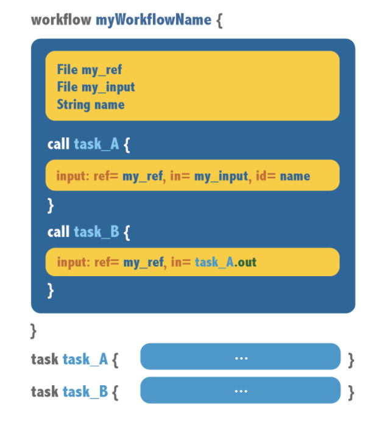

**Calls** are defined within the **Workflow** block and **tasks** are defined outside of it. **Calls** are used to specify that a particular **task** should be executed. **Calls** can also contain input variables for your **tasks**.

**Tasks** consist of **command**, **runtime**, and **output** components.

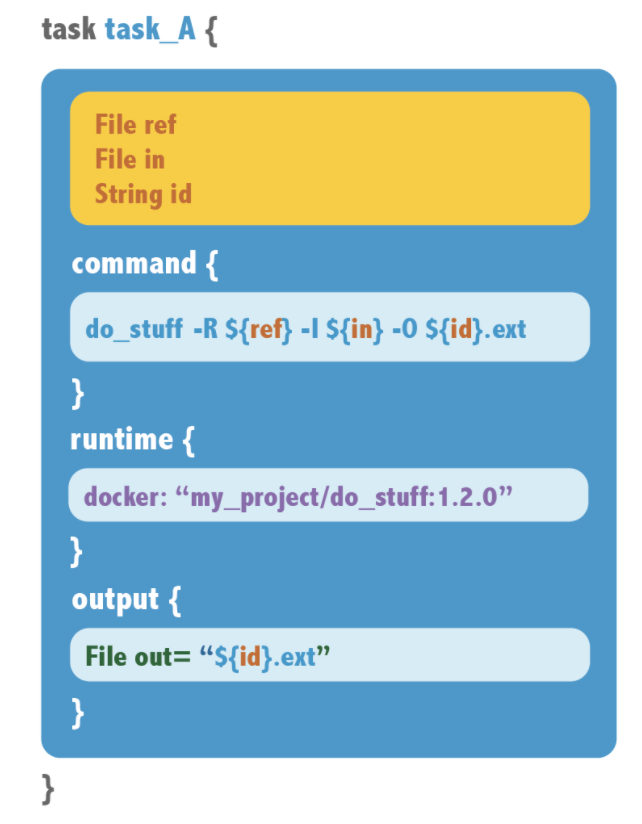

The **command** section defines what will be done, this can be a command that is used in any shell script for example.

The **runtime** section is used to define your **task** parameters such as the docker image, memory, and CPUs you need to run the **task**.

The **output** section is used to define the files that you want output from the **task**.

## Example of a Workflow for converting VCFs to Plink2 files

First, we define the inputs and specify some runtime attributes.

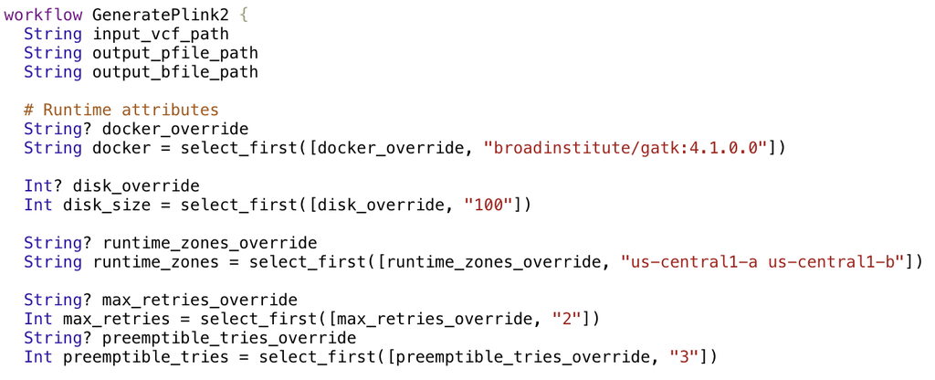

Second, we define the calls, which just tells the workflow which tasks you want to execute.

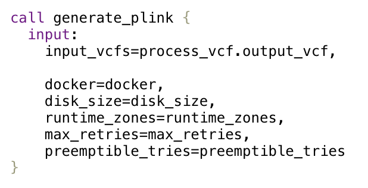

Third, we define what our task 'generate_plink' does.

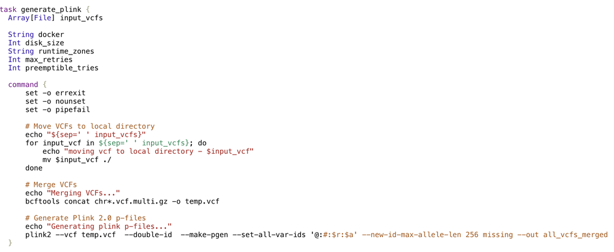

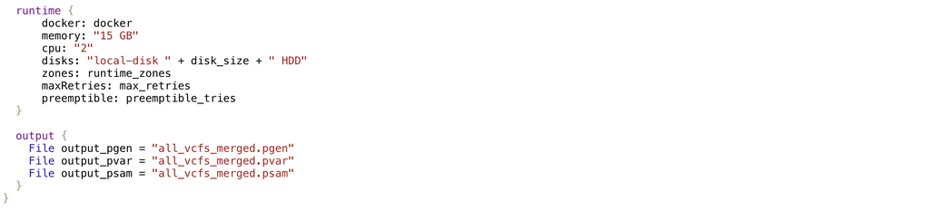

# How to use available workflows

Terra has a few premade Workflows that you can use, or you can browse the public methods on the Broad Repository.

[figure not shown]

If you find one on Terra you want, simply click the 'Add to Workspace' button. If you find one in the Broad repository, click 'Export to Workspace' then select 'Use Blank Configuration'.

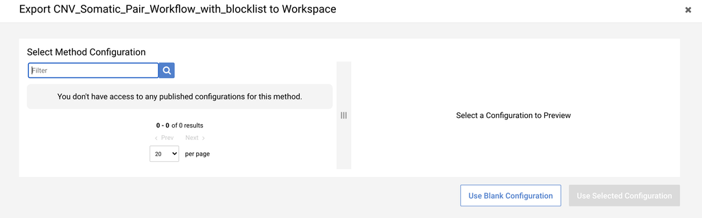

Next choose the workspace you want to export to and click 'Export to Workspace'.

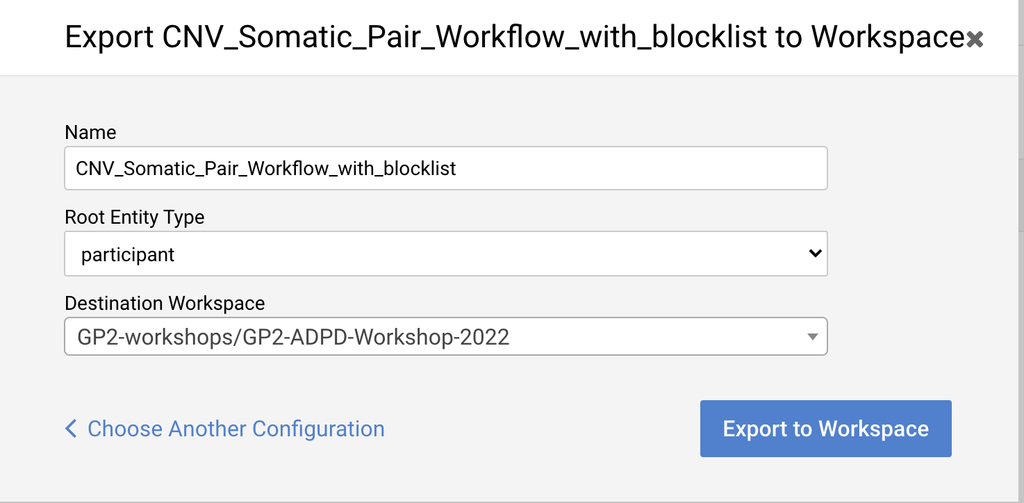

Now your workflow will be ready to set up and run! Let's learn how to make our own and practice running it.

# Demo - make and run your own workflow

To create a new workflow navigate to the Broad Methods Repository and click 'Create New Method'

[figure not shown]

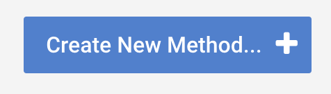

We are going to practice writing a workflow that prints your name. Try creating a workflow and writing out the example below:

```
#WORKFLOW DEFINITION
workflow PrintName {
    String first_name
    String last_name

    call hello {
        input:
            first_name=first_name,
            last_name=last_name
  }
}

#TASK
task hello {
    String first_name
    String last_name

    command {
        echo 'Hello ${first_name} ${last_name}!'
  }
    output {
        File response = stdout()
  }
    runtime {
        docker: "google/cloud-sdk:slim"
  }
}
```

The final product should look something like this:

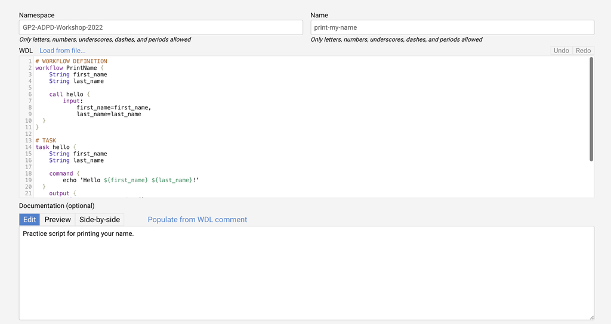

Save and export your workflow to your workspace. Next we can submit it like below:

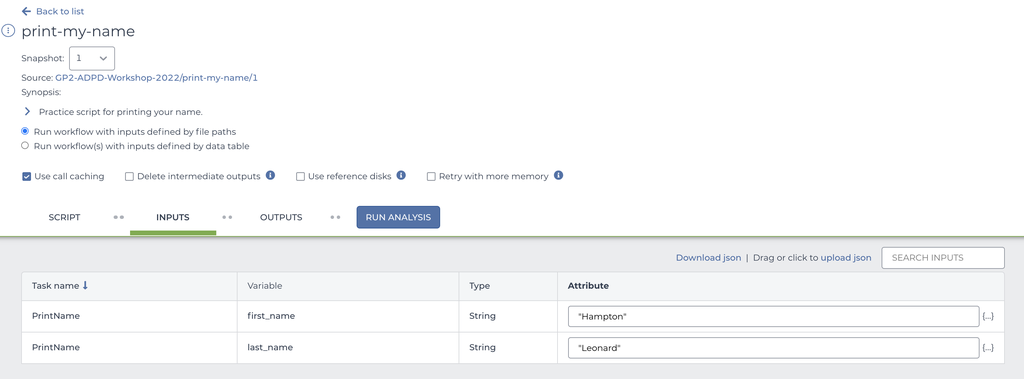

Now you can monitor your workflow under the 'Job History' tab. When a workflow has succeeded it looks like this:

[figure not shown]

Outputs are written to your workspace bucket. Navigate back to your workspace bucket under the 'Data' tab and select the folder that matches the Submission ID. Next select the call that you want to see the output for. Our output was stdout() so take a look at the stdout file to see how things look.

[figure not shown]

Our workflow worked!

You can also estimate how much your Workflow will cost using a premade notebook! Copy [this notebook](https://app.terra.bio/#workspaces/biodata-catalyst/BioData%20Catalyst%20Collection/notebooks/launch/Workflow%20Cost%20Estimator.ipynb) to your workspace and run a test workflow. You can then use the job submission ID to estimate different parameters and longer versions of the workflow.

Terra has a lot of resources for learning to use Workflows - make sure to check them out for more detailed information: https://support.terra.bio/hc/en-us/sections/360004147011-Workflows